# Introduction

[figure not shown]

We have a lot of topics to cover over the next two days, so the purpose of this course is to give you the full pipeline of development for a data scientist using a practical use case scenario.

Why Data Science now?

[figure not shown]

[figure not shown]

Why Data Science with Python

[figure not shown]

## Customizing your Notebook Environment

Get your notebook up and running with Anaconda

https://www.anaconda.com/download/

[figure not shown]

https://notebooks.azure.com/

start your jupyter-notebook

Some functions with your Jupyter Notebook

Create files, folders, and functions

### Jupyter Notebook Functions: There are plenty

## Day 1 -> Section 1 -> Demo 1

### on Windows

C:\Users\Ahmed Sherif>conda create --name AhmedDataScience python=3.6.1

activate AhmedDataScience

### on mac or linux

ahmed sherif$ conda create --name AhmedDataScience python=3.6.1

source activate AhmedDataScience

### End of Demo 1

## Day 1 -> Section 2 -> Demo 2

pip install ipykernel

### on mac/linux/windows

python –m ipykernel install -- user --name

pip list

pip freeze

### General Python Functionality readily available in Python

```python
print('hello world')
```

```
hello world
```

```python
print(5, type(5))
```

```
5 <class 'int'>
```

```python
print(True, type(True))
```

```
True <class 'bool'>
```

```python
instructor = 'Ahmed'
```

```python
print('Hello, my name is '+ instructor +'\nand I am looking forward to meeting you!')
```

```
Hello, my name is Ahmed
and I am looking forward to meeting you!
```

```python
print(f'Hello, my name is {instructor}\nand I am looking forward to meeting you!')
```

```
Hello, my name is Ahmed
and I am looking forward to meeting you!
```

```python
age = 40
```

```python
print('Hello, my name is Ahmed Sherif and I am '+str(age)+' years old')
```

```
Hello, my name is Ahmed Sherif and I am 40 years old
```

```python
print(f'Hello, my name is Ahmed Sherif and I am {age/2} years old')
```

```
Hello, my name is Ahmed Sherif and I am 20.0 years old
```

```python
'f strings as of version 3.6'
```

```
'f strings as of version 3.6'
```

## import your Dataset and much needed libraries

```python
!pip list
```

[output not shown]

[output cut: 207 more lines]

[output not shown]

```python
!pip install numpy
!pip install pandas
!pip install matplotlib
!pip install sklearn
```

```python
import pandas as pd
import matplotlib
import matplotlib.pyplot as plt
import numpy as np
import sklearn
```

```python
!pip list
```

[output not shown]

[output cut: 207 more lines]

[output not shown]

```python
print(f'pandas version: {pd.__version__}')
print(f'matplotlib version: {matplotlib.__version__}')

print(f'numpy version: {np.__version__}')
```

```
pandas version: 0.23.4
matplotlib version: 3.0.2
numpy version: 1.16.0
```

## I am cool

```python
"""
helllo, i am cool!
asdfasdfasdfa
            asfasdf



"""
```

```
'\nhelllo, i am cool!\nasdfasdfasdfa\n            asfasdf\n            \n            \n\n'
```

# End of Demo 2

## Day 1 -> Section 3 -> Demo 3

## Data Profiling

```python
# describe what the data is about
```

https://www.kaggle.com/zynicide/wine-reviews

country: The country that the wine is from description: Notes from the Tasters designation: The vineyard within the winery where the grapes that made the wine are from points: The number of points WineEnthusiast rated the wine on a scale of 1-100 (though they say they only post reviews for wines that score >=80) price: The cost for a bottle of the wine province: The province or state that the wine is from region_1: The wine growing area in a province or state (ie Napa) region_2: Sometimes there are more specific regions specified within a wine growing area (ie Rutherford inside the Napa Valley), but this value can sometimes be blank taster_name: taster_twitter_handle: title: The title of the wine review, which often contains the vintage if you're interested in extracting that feature variety: The type of grapes used to make the wine (ie Pinot Noir) winery: The winery that made the wine

https://raw.githubusercontent.com/asherif844/DataScienceWithPython/master/winemag.csv

## import the dataframe from a .csv file locally or from a website like GitHub

```python
%ls
```

```
Data Science Notebook  - Day 1.ipynb  images/
DataScienceTutorial.ipynb*            modelLR.pkl*
Presentation.ipynb*                   winemag.csv*
Tutorial for Data Science.ipynb*
```

```python
df = pd.read_csv('winemag.csv')
```

or you can use the following instead

```python
df = pd.read_csv('https://raw.githubusercontent.com/asherif844/DataScienceWithPython/master/winemag.csv')
```

```python
speaker = 'ahmed'
```

```python
df.head()
```

|  | Unnamed: 0 | country | description | designation | points | price | province | region_1 | region_2 | taster_name | taster_twitter_handle | title | variety | winery |
| --- | --- | --- | --- | --- | --- | --- | --- | --- | --- | --- | --- | --- | --- | --- |
| 0 | 0 | Italy | Aromas include tropical fruit, broom, brimston... | Vulkà Bianco | 87 | NaN | Sicily & Sardinia | Etna | NaN | Kerin O’Keefe | @kerinokeefe | Nicosia 2013 Vulkà Bianco (Etna) | White Blend | Nicosia |
| 1 | 1 | Portugal | This is ripe and fruity, a wine that is smooth... | Avidagos | 87 | 15.0 | Douro | NaN | NaN | Roger Voss | @vossroger | Quinta dos Avidagos 2011 Avidagos Red (Douro) | Portuguese Red | Quinta dos Avidagos |
| 2 | 2 | US | Tart and snappy, the flavors of lime flesh and... | NaN | 87 | 14.0 | Oregon | Willamette Valley | Willamette Valley | Paul Gregutt | @paulgwine | Rainstorm 2013 Pinot Gris (Willamette Valley) | Pinot Gris | Rainstorm |
| 3 | 3 | US | Pineapple rind, lemon pith and orange blossom ... | Reserve Late Harvest | 87 | 13.0 | Michigan | Lake Michigan Shore | NaN | Alexander Peartree | NaN | St. Julian 2013 Reserve Late Harvest Riesling ... | Riesling | St. Julian |
| 4 | 4 | US | Much like the regular bottling from 2012, this... | Vintner's Reserve Wild Child Block | 87 | 65.0 | Oregon | Willamette Valley | Willamette Valley | Paul Gregutt | @paulgwine | Sweet Cheeks 2012 Vintner's Reserve Wild Child... | Pinot Noir | Sweet Cheeks |

```python
df.tail()
```

|  | Unnamed: 0 | country | description | designation | points | price | province | region_1 | region_2 | taster_name | taster_twitter_handle | title | variety | winery |
| --- | --- | --- | --- | --- | --- | --- | --- | --- | --- | --- | --- | --- | --- | --- |
| 129966 | 129966 | Germany | Notes of honeysuckle and cantaloupe sweeten th... | Brauneberger Juffer-Sonnenuhr Spätlese | 90 | 28.0 | Mosel | NaN | NaN | Anna Lee C. Iijima | NaN | Dr. H. Thanisch (Erben Müller-Burggraef) 2013 ... | Riesling | Dr. H. Thanisch (Erben Müller-Burggraef) |
| 129967 | 129967 | US | Citation is given as much as a decade of bottl... | NaN | 90 | 75.0 | Oregon | Oregon | Oregon Other | Paul Gregutt | @paulgwine | Citation 2004 Pinot Noir (Oregon) | Pinot Noir | Citation |
| 129968 | 129968 | France | Well-drained gravel soil gives this wine its c... | Kritt | 90 | 30.0 | Alsace | Alsace | NaN | Roger Voss | @vossroger | Domaine Gresser 2013 Kritt Gewurztraminer (Als... | Gewürztraminer | Domaine Gresser |
| 129969 | 129969 | France | A dry style of Pinot Gris, this is crisp with ... | NaN | 90 | 32.0 | Alsace | Alsace | NaN | Roger Voss | @vossroger | Domaine Marcel Deiss 2012 Pinot Gris (Alsace) | Pinot Gris | Domaine Marcel Deiss |
| 129970 | 129970 | France | Big, rich and off-dry, this is powered by inte... | Lieu-dit Harth Cuvée Caroline | 90 | 21.0 | Alsace | Alsace | NaN | Roger Voss | @vossroger | Domaine Schoffit 2012 Lieu-dit Harth Cuvée Car... | Gewürztraminer | Domaine Schoffit |

```python
df.head(3)
```

|  | Unnamed: 0 | country | description | designation | points | price | province | region_1 | region_2 | taster_name | taster_twitter_handle | title | variety | winery |
| --- | --- | --- | --- | --- | --- | --- | --- | --- | --- | --- | --- | --- | --- | --- |
| 0 | 0 | Italy | Aromas include tropical fruit, broom, brimston... | Vulkà Bianco | 87 | NaN | Sicily & Sardinia | Etna | NaN | Kerin O’Keefe | @kerinokeefe | Nicosia 2013 Vulkà Bianco (Etna) | White Blend | Nicosia |
| 1 | 1 | Portugal | This is ripe and fruity, a wine that is smooth... | Avidagos | 87 | 15.0 | Douro | NaN | NaN | Roger Voss | @vossroger | Quinta dos Avidagos 2011 Avidagos Red (Douro) | Portuguese Red | Quinta dos Avidagos |
| 2 | 2 | US | Tart and snappy, the flavors of lime flesh and... | NaN | 87 | 14.0 | Oregon | Willamette Valley | Willamette Valley | Paul Gregutt | @paulgwine | Rainstorm 2013 Pinot Gris (Willamette Valley) | Pinot Gris | Rainstorm |

## slicing and dicing

```python
# use iloc (numbers)
```

```python
df.iloc[100:105, 0:3]
```

|  | Unnamed: 0 | country | description |
| --- | --- | --- | --- |
| 100 | 100 | US | Fresh apple, lemon and pear flavors are accent... |
| 101 | 101 | US | Dusty mineral, smoke and struck flint lend a s... |
| 102 | 102 | US | Intensely smoky tones of struck flint and ash ... |
| 103 | 103 | Chile | A bright nose with green apple and citric arom... |
| 104 | 104 | Italy | Made with 65% Sangiovese, 20% Merlot and 15% C... |

```python
# use loc (column header names)
```

```python
df.loc[100:105, ['country', 'description', 'taster_name']]
```

|  | country | description | taster_name |
| --- | --- | --- | --- |
| 100 | US | Fresh apple, lemon and pear flavors are accent... | Anna Lee C. Iijima |
| 101 | US | Dusty mineral, smoke and struck flint lend a s... | Anna Lee C. Iijima |
| 102 | US | Intensely smoky tones of struck flint and ash ... | Anna Lee C. Iijima |
| 103 | Chile | A bright nose with green apple and citric arom... | Michael Schachner |
| 104 | Italy | Made with 65% Sangiovese, 20% Merlot and 15% C... | Kerin O’Keefe |
| 105 | Italy | Made predominantly with Trebbiano and Malvasia... | Kerin O’Keefe |

```python
df.describe()
```

|  | Unnamed: 0 | points | price |
| --- | --- | --- | --- |
| count | 129971.000000 | 129971.000000 | 120975.000000 |
| mean | 64985.000000 | 88.447138 | 35.363389 |
| std | 37519.540256 | 3.039730 | 41.022218 |
| min | 0.000000 | 80.000000 | 4.000000 |
| 25% | 32492.500000 | 86.000000 | 17.000000 |
| 50% | 64985.000000 | 88.000000 | 25.000000 |
| 75% | 97477.500000 | 91.000000 | 42.000000 |
| max | 129970.000000 | 100.000000 | 3300.000000 |

```python
df.info()
```

```
<class 'pandas.core.frame.DataFrame'>
RangeIndex: 129971 entries, 0 to 129970
Data columns (total 14 columns):
Unnamed: 0               129971 non-null int64
country                  129908 non-null object
description              129971 non-null object
designation              92506 non-null object
points                   129971 non-null int64
price                    120975 non-null float64
province                 129908 non-null object
region_1                 108724 non-null object
region_2                 50511 non-null object
taster_name              103727 non-null object
taster_twitter_handle    98758 non-null object
title                    129971 non-null object
variety                  129970 non-null object
winery                   129971 non-null object
dtypes: float64(1), int64(2), object(11)
memory usage: 13.9+ MB
```

```python
df.columns
```

```
Index(['Unnamed: 0', 'country', 'description', 'designation', 'points',
       'price', 'province', 'region_1', 'region_2', 'taster_name',
       'taster_twitter_handle', 'title', 'variety', 'winery'],
      dtype='object')
```

```python
df[['price', 'points']]
```

|  | price | points |
| --- | --- | --- |
| 0 | NaN | 87 |
| 1 | 15.0 | 87 |
| 2 | 14.0 | 87 |
| 3 | 13.0 | 87 |
| 4 | 65.0 | 87 |
| 5 | 15.0 | 87 |
| 6 | 16.0 | 87 |
| 7 | 24.0 | 87 |
| 8 | 12.0 | 87 |
| 9 | 27.0 | 87 |
| 10 | 19.0 | 87 |
| 11 | 30.0 | 87 |
| 12 | 34.0 | 87 |
| 13 | NaN | 87 |
| 14 | 12.0 | 87 |
| 15 | 24.0 | 87 |
| 16 | 30.0 | 87 |
| 17 | 13.0 | 87 |
| 18 | 28.0 | 87 |
| 19 | 32.0 | 87 |
| 20 | 23.0 | 87 |
| 21 | 20.0 | 87 |
| 22 | 19.0 | 87 |
| 23 | 22.0 | 87 |
| 24 | 35.0 | 87 |
| 25 | 69.0 | 87 |
| 26 | 13.0 | 87 |
| 27 | 10.0 | 87 |
| 28 | 17.0 | 87 |
| 29 | 16.0 | 86 |
| ... | ... | ... |
| 129941 | 20.0 | 90 |
| 129942 | 35.0 | 90 |
| 129943 | 29.0 | 90 |
| 129944 | 25.0 | 90 |
| 129945 | 20.0 | 90 |
| 129946 | 17.0 | 90 |
| 129947 | 20.0 | 90 |
| 129948 | 43.0 | 90 |
| 129949 | 35.0 | 90 |
| 129950 | 35.0 | 90 |
| 129951 | 30.0 | 90 |
| 129952 | 22.0 | 90 |
| 129953 | 25.0 | 90 |
| 129954 | 15.0 | 90 |
| 129955 | 40.0 | 90 |
| 129956 | 19.0 | 90 |
| 129957 | 17.0 | 90 |
| 129958 | 35.0 | 90 |
| 129959 | 57.0 | 90 |
| 129960 | 48.0 | 90 |
| 129961 | 30.0 | 90 |
| 129962 | 40.0 | 90 |
| 129963 | 20.0 | 90 |
| 129964 | NaN | 90 |
| 129965 | 28.0 | 90 |
| 129966 | 28.0 | 90 |
| 129967 | 75.0 | 90 |
| 129968 | 30.0 | 90 |
| 129969 | 32.0 | 90 |
| 129970 | 21.0 | 90 |

129971 rows × 2 columns

```python
print(df.describe())
print(df.info())
```

```
          Unnamed: 0         points          price
count  129971.000000  129971.000000  120975.000000
mean    64985.000000      88.447138      35.363389
std     37519.540256       3.039730      41.022218
min         0.000000      80.000000       4.000000
25%     32492.500000      86.000000      17.000000
50%     64985.000000      88.000000      25.000000
75%     97477.500000      91.000000      42.000000
max    129970.000000     100.000000    3300.000000
<class 'pandas.core.frame.DataFrame'>
RangeIndex: 129971 entries, 0 to 129970
Data columns (total 14 columns):
Unnamed: 0               129971 non-null int64
country                  129908 non-null object
description              129971 non-null object
designation              92506 non-null object
points                   129971 non-null int64
price                    120975 non-null float64
province                 129908 non-null object
region_1                 108724 non-null object
region_2                 50511 non-null object
taster_name              103727 non-null object
taster_twitter_handle    98758 non-null object
title                    129971 non-null object
variety                  129970 non-null object
winery                   129971 non-null object
dtypes: float64(1), int64(2), object(11)
memory usage: 13.9+ MB
None
```

```python
df.describe()
```

|  | Unnamed: 0 | points | price |
| --- | --- | --- | --- |
| count | 129971.000000 | 129971.000000 | 120975.000000 |
| mean | 64985.000000 | 88.447138 | 35.363389 |
| std | 37519.540256 | 3.039730 | 41.022218 |
| min | 0.000000 | 80.000000 | 4.000000 |
| 25% | 32492.500000 | 86.000000 | 17.000000 |
| 50% | 64985.000000 | 88.000000 | 25.000000 |
| 75% | 97477.500000 | 91.000000 | 42.000000 |
| max | 129970.000000 | 100.000000 | 3300.000000 |

```python
df.info()
```

```
<class 'pandas.core.frame.DataFrame'>
RangeIndex: 129971 entries, 0 to 129970
Data columns (total 14 columns):
Unnamed: 0               129971 non-null int64
country                  129908 non-null object
description              129971 non-null object
designation              92506 non-null object
points                   129971 non-null int64
price                    120975 non-null float64
province                 129908 non-null object
region_1                 108724 non-null object
region_2                 50511 non-null object
taster_name              103727 non-null object
taster_twitter_handle    98758 non-null object
title                    129971 non-null object
variety                  129970 non-null object
winery                   129971 non-null object
dtypes: float64(1), int64(2), object(11)
memory usage: 13.9+ MB
```

# Data Cleansing & Data Wrangling

https://www.forbes.com/sites/gilpress/2016/03/23/data-preparation-most-time-consuming-least-enjoyable-data-science-task-survey-says/#620c94ce6f63

## Day 1 -> Section 3 -> Lab 1

```python
# drop some data that you won't need because there are so many missing values
```

1. Data Analysis on Dataframe using pandas 2. Identifying erroneous data 3. Replacing and Imputing Erroneous data 4. Discuss the concept of ‘Tyranny of the Mean’

## For Loops and If statements in Python (psst....they are much easier than in other languages)

```python
# identify null values
```

```python
df.info()
```

```
<class 'pandas.core.frame.DataFrame'>
RangeIndex: 129971 entries, 0 to 129970
Data columns (total 14 columns):
Unnamed: 0               129971 non-null int64
country                  129908 non-null object
description              129971 non-null object
designation              92506 non-null object
points                   129971 non-null int64
price                    120975 non-null float64
province                 129908 non-null object
region_1                 108724 non-null object
region_2                 50511 non-null object
taster_name              103727 non-null object
taster_twitter_handle    98758 non-null object
title                    129971 non-null object
variety                  129970 non-null object
winery                   129971 non-null object
dtypes: float64(1), int64(2), object(11)
memory usage: 13.9+ MB
```

```python
import this
```

```
The Zen of Python, by Tim Peters

Beautiful is better than ugly.
Explicit is better than implicit.
Simple is better than complex.
Complex is better than complicated.
Flat is better than nested.
Sparse is better than dense.
Readability counts.
Special cases aren't special enough to break the rules.
Although practicality beats purity.
Errors should never pass silently.
Unless explicitly silenced.
In the face of ambiguity, refuse the temptation to guess.
There should be one-- and preferably only one --obvious way to do it.
Although that way may not be obvious at first unless you're Dutch.
Now is better than never.
Although never is often better than *right* now.
If the implementation is hard to explain, it's a bad idea.
If the implementation is easy to explain, it may be a good idea.
Namespaces are one honking great idea -- let's do more of those!
```

```python
for column in df.columns:
    if df[column].isnull().any():
        print(f'{column} has {df[column].isnull().sum()} null values')
    else:
        print(f'{column} has no missing values!!!')
```

```
Unnamed: 0 has no missing values!!!
country has 63 null values
description has no missing values!!!
designation has 37465 null values
points has no missing values!!!
price has 8996 null values
province has 63 null values
region_1 has 21247 null values
region_2 has 79460 null values
taster_name has 26244 null values
taster_twitter_handle has 31213 null values
title has no missing values!!!
variety has 1 null values
winery has no missing values!!!
```

```python
bad_columns = []
```

```python
for column in df.columns:
    if df[column].isnull().sum()>=20000:
        bad_columns.append(column)
```

```python
print(bad_columns)
```

```
['designation', 'region_1', 'region_2', 'taster_name', 'taster_twitter_handle']
```

```python
bad_columns.append('Unnamed: 0')
```

```python
bad_columns.remove('region_1')
```

```python
print(bad_columns)
```

```
['designation', 'region_2', 'taster_name', 'taster_twitter_handle', 'Unnamed: 0']
```

```python
df = df.drop(bad_columns, axis = 1)
```

```python
df.head()
```

|  | country | description | points | price | province | region_1 | title | variety | winery |
| --- | --- | --- | --- | --- | --- | --- | --- | --- | --- |
| 0 | Italy | Aromas include tropical fruit, broom, brimston... | 87 | NaN | Sicily & Sardinia | Etna | Nicosia 2013 Vulkà Bianco (Etna) | White Blend | Nicosia |
| 1 | Portugal | This is ripe and fruity, a wine that is smooth... | 87 | 15.0 | Douro | NaN | Quinta dos Avidagos 2011 Avidagos Red (Douro) | Portuguese Red | Quinta dos Avidagos |
| 2 | US | Tart and snappy, the flavors of lime flesh and... | 87 | 14.0 | Oregon | Willamette Valley | Rainstorm 2013 Pinot Gris (Willamette Valley) | Pinot Gris | Rainstorm |
| 3 | US | Pineapple rind, lemon pith and orange blossom ... | 87 | 13.0 | Michigan | Lake Michigan Shore | St. Julian 2013 Reserve Late Harvest Riesling ... | Riesling | St. Julian |
| 4 | US | Much like the regular bottling from 2012, this... | 87 | 65.0 | Oregon | Willamette Valley | Sweet Cheeks 2012 Vintner's Reserve Wild Child... | Pinot Noir | Sweet Cheeks |

```python
df.info()
```

```
<class 'pandas.core.frame.DataFrame'>
RangeIndex: 129971 entries, 0 to 129970
Data columns (total 9 columns):
country        129908 non-null object
description    129971 non-null object
points         129971 non-null int64
price          120975 non-null float64
province       129908 non-null object
region_1       108724 non-null object
title          129971 non-null object
variety        129970 non-null object
winery         129971 non-null object
dtypes: float64(1), int64(1), object(7)
memory usage: 8.9+ MB
```

```python
df.describe()
```

|  | points | price |
| --- | --- | --- |
| count | 129971.000000 | 120975.000000 |
| mean | 88.447138 | 35.363389 |
| std | 3.039730 | 41.022218 |
| min | 80.000000 | 4.000000 |
| 25% | 86.000000 | 17.000000 |
| 50% | 88.000000 | 25.000000 |
| 75% | 91.000000 | 42.000000 |
| max | 100.000000 | 3300.000000 |

```python
df['price'].notnull()
```

```
0         False
1          True
2          True
3          True
4          True
5          True
6          True
7          True
8          True
9          True
10         True
11         True
12         True
13        False
14         True
```

[output cut: 47 more lines]

```python
df['price'].isnull()
```

```
0          True
1         False
2         False
3         False
4         False
5         False
6         False
7         False
8         False
9         False
10        False
11        False
12        False
13         True
14        False
```

[output cut: 47 more lines]

```python
df[df['price'].isnull()]
```

|  | country | description | points | price | province | region_1 | title | variety | winery |
| --- | --- | --- | --- | --- | --- | --- | --- | --- | --- |
| 0 | Italy | Aromas include tropical fruit, broom, brimston... | 87 | NaN | Sicily & Sardinia | Etna | Nicosia 2013 Vulkà Bianco (Etna) | White Blend | Nicosia |
| 13 | Italy | This is dominated by oak and oak-driven aromas... | 87 | NaN | Sicily & Sardinia | Etna | Masseria Setteporte 2012 Rosso (Etna) | Nerello Mascalese | Masseria Setteporte |
| 30 | France | Red cherry fruit comes laced with light tannin... | 86 | NaN | Beaujolais | Beaujolais-Villages | Domaine de la Madone 2012 Nouveau (Beaujolais... | Gamay | Domaine de la Madone |
| 31 | Italy | Merlot and Nero d'Avola form the base for this... | 86 | NaN | Sicily & Sardinia | Sicilia | Duca di Salaparuta 2010 Calanìca Nero d'Avola-... | Red Blend | Duca di Salaparuta |
| 32 | Italy | Part of the extended Calanìca series, this Gri... | 86 | NaN | Sicily & Sardinia | Sicilia | Duca di Salaparuta 2011 Calanìca Grillo-Viogni... | White Blend | Duca di Salaparuta |
| 50 | Italy | This blend of Nero d'Avola and Syrah opens wit... | 86 | NaN | Sicily & Sardinia | Sicilia | Viticultori Associati Canicatti 2008 Scialo Re... | Red Blend | Viticultori Associati Canicatti |
| 54 | Italy | A blend of Nero d'Avola and Nerello Mascalese,... | 85 | NaN | Sicily & Sardinia | Sicilia | Corvo 2010 Rosso Red (Sicilia) | Red Blend | Corvo |
| 79 | Portugal | Grown on the sandy soil of Tejo, the wine is t... | 86 | NaN | Tejo | NaN | Adega Cooperativa do Cartaxo 2014 Bridão Touri... | Touriga Nacional | Adega Cooperativa do Cartaxo |
| 137 | South Africa | This is great Chenin Blanc, wood fermented but... | 90 | NaN | Walker Bay | NaN | Beaumont 2005 Hope Marguerite Chenin Blanc (Wa... | Chenin Blanc | Beaumont |
| 159 | Italy | Intense aromas of ripe red berry, menthol, esp... | 91 | NaN | Tuscany | Brunello di Montalcino | Castello Romitorio 2011 Filo di Seta (Brunell... | Sangiovese | Castello Romitorio |
| 163 | France | Produced from vineyards donated to a charitabl... | 91 | NaN | Beaujolais | Moulin-à-Vent | Collin-Bourisset 2011 Hospices Civils de Roman... | Gamay | Collin-Bourisset |
| 182 | Italy | Loaded with bold, ripe fruit, exotic spice and... | 88 | NaN | Tuscany | Brunello di Montalcino | Abbadia Ardenga 2003 M. Vigna (Brunello di Mo... | Sangiovese Grosso | Abbadia Ardenga |
| 194 | Italy | Here's a traditional Chianti Classico with pre... | 87 | NaN | Tuscany | Chianti Classico | Campomaggio 2005 Chianti Classico | Sangiovese | Campomaggio |
| 200 | Italy | Aromas of mature black-skinned berry, tobacco ... | 90 | NaN | Tuscany | Brunello di Montalcino | Tenuta di Sesta 2011 Riserva (Brunello di Mon... | Sangiovese | Tenuta di Sesta |
| 222 | Italy | Chopped herb, forest floor, leather, espresso ... | 90 | NaN | Tuscany | Brunello di Montalcino | Talenti 2011 Trentennale (Brunello di Montalc... | Sangiovese | Talenti |
| 223 | Italy | Bright and creamy, this savory white offers ar... | 90 | NaN | Northeastern Italy | Alto Adige | Terlan 2015 Pinot Bianco (Alto Adige) | Pinot Bianco | Terlan |
| 285 | Austria | This is a very aromatic wine that's rich, spic... | 92 | NaN | Kremstal | NaN | Salomon-Undhof 2011 Steiner Kögl Erste Lage Ri... | Riesling | Salomon-Undhof |
| 288 | Austria | While it feels rich and round, this is also a ... | 92 | NaN | Kremstal | NaN | Josef Schmid 2011 Kremser Gebling Erste Lage G... | Grüner Veltliner | Josef Schmid |
| 290 | France | This is a wine that has great potential—you ca... | 92 | NaN | Bordeaux | Saint-Estèphe | Château Lafon-Rochet 2011 Saint-Estèphe | Bordeaux-style Red Blend | Château Lafon-Rochet |
| 291 | Italy | This powerful Sagrantino opens with aromas of ... | 92 | NaN | Central Italy | Sagrantino di Montefalco | Dionigi 2006 Sagrantino di Montefalco | Sagrantino | Dionigi |
| 299 | Italy | Pinay is a tight and defined red blend from no... | 87 | NaN | Piedmont | Langhe | Attilio Ghisolfi 2007 Pinay Red (Langhe) | Red Blend | Attilio Ghisolfi |
| 302 | Italy | This fresh Nebbiolo-based Roero from Cantina d... | 87 | NaN | Piedmont | Roero | Cantina del Nebbiolo 2008 Roero | Nebbiolo | Cantina del Nebbiolo |
| 304 | Italy | This aged expression from the Nizza subzone of... | 87 | NaN | Piedmont | Barbera d'Asti Superiore Nizza | Cascina La Ghersa 2004 Vignassa (Barbera d'As... | Barbera | Cascina La Ghersa |
| 313 | Italy | Roero Rabino is accented by sweet touches of c... | 87 | NaN | Piedmont | Roero | Rabino 2008 Roero | Nebbiolo | Rabino |
| 316 | France | An intriguing blend of Sauvignon Blanc and Mus... | 86 | NaN | Bordeaux | Bordeaux Blanc | Château Mont-Pérat 2008 Les Amants Mont-Pérat ... | Bordeaux-style White Blend | Château Mont-Pérat |
| 317 | France | Soft, ripe, dominated by peaches, pears and a ... | 86 | NaN | Bordeaux | Bordeaux Blanc | Château Tour de Mirambeau 2006 Bordeaux Blanc | Bordeaux-style White Blend | Château Tour de Mirambeau |
| 377 | Greece | A fresh, tangy, vibrant wine that has ripe gre... | 88 | NaN | Naoussa | NaN | Zenato 2001 Vigneto Massoni White (Naoussa) | White Blend | Zenato |
| 395 | Italy | This is the first vintage of this blend of Cha... | 87 | NaN | Northeastern Italy | Collio | Conti Formentini 2001 Rylint White (Collio) | White Blend | Conti Formentini |
| 417 | Italy | This is a sweet style of Prosecco with a lumin... | 85 | NaN | Veneto | Prosecco del Veneto | Pizzolato NV Prosecco del Veneto | Prosecco | Pizzolato |
| 418 | Austria | Using many biodynamic practices, Werner Michli... | 85 | NaN | Burgenland | NaN | Michlits 2007 Biokult Zweigelt Pinot Noir Red ... | Red Blend | Michlits |
| ... | ... | ... | ... | ... | ... | ... | ... | ... | ... |
| 129371 | Austria | A perfumed wine from the Krems Vineyards, with... | 87 | NaN | Kremstal | NaN | Forstreiter 2011 Donau Riesling Riesling (Krem... | Riesling | Forstreiter |
| 129383 | France | The entry-level wine from Château d'Esclans, t... | 87 | NaN | Provence | Côtes de Provence | Château d'Esclans 2011 Whispering Angel Rosé (... | Rosé | Château d'Esclans |
| 129384 | France | This is a textured wine that's rich and round.... | 87 | NaN | Provence | Côtes de Provence | Château la Tour de l'Evêque 2011 Pétale de Ros... | Rosé | Château la Tour de l'Evêque |
| 129387 | Italy | This is a broad, round Prosecco that doesn't o... | 85 | NaN | Veneto | Prosecco del Veneto | Vigneti Fantinel NV Extra Dry (Prosecco del V... | Prosecco | Vigneti Fantinel |
| 129388 | Argentina | Slightly tart and like rhubarb at first, but i... | 85 | NaN | Mendoza Province | Mendoza | Antigal 2006 Aduentus Classic Red (Mendoza) | Red Blend | Antigal |
| 129395 | Italy | This Prosecco Extra Dry has full notes of almo... | 85 | NaN | Veneto | Prosecco di Valdobbiadene | La Riva dei Frati NV Extra Dry (Prosecco di V... | Prosecco | La Riva dei Frati |
| 129432 | Italy | Earthy aromas of wild berry, underbrush, leath... | 89 | NaN | Piedmont | Barolo | Ascheri 2013 Sorano (Barolo) | Nebbiolo | Ascheri |
| 129469 | France | Alain Thiénot's non vintage is ripe, rich and ... | 88 | NaN | Champagne | Champagne | Thiénot NV Brut (Champagne) | Champagne Blend | Thiénot |
| 129488 | Portugal | A spicy, ripe wine that is part of the second ... | 88 | NaN | Douro | NaN | Quinta de la Rosa 2011 DouRosa Red (Douro) | Portuguese Red | Quinta de la Rosa |
| 129512 | Italy | This opens with aroma suggesting raw oak and t... | 88 | NaN | Piedmont | Barolo | Gemma 2008 Gibin Riserva (Barolo) | Nebbiolo | Gemma |
| 129519 | Portugal | The 12-months of oak aging has given this wine... | 88 | NaN | Península de Setúbal | NaN | Cooperativa Agricola de Santo Isidro de Pegoes... | Touriga Nacional | Cooperativa Agricola de Santo Isidro de Pegoes |
| 129525 | France | This is a powerful, big-hearted Malbec, full o... | 89 | NaN | France Other | Vin de France | Lionel Osmin & Cie 2011 Pont du Diable Malbec ... | Malbec | Lionel Osmin & Cie |
| 129552 | Italy | Fragrant blue flower, rose, new leather, cake ... | 93 | NaN | Piedmont | Barolo | Rivetto 2013 del Comune di Serralunga d'Alba ... | Nebbiolo | Rivetto |
| 129610 | Italy | La Fagiana is a bright, ruby-colored wine with... | 84 | NaN | Tuscany | Toscana | Fattoria di San Quintino 2008 La Fagiana Red (... | Red Blend | Fattoria di San Quintino |
| 129638 | France | Very rich and packed with yellow and tropical ... | 90 | NaN | Southwest France | Bergerac Sec | Château Tour des Gendres 2011 Moulin des Dames... | Bordeaux-style White Blend | Château Tour des Gendres |
| 129684 | France | This concentrated, full-bodied wine has fine, ... | 93 | NaN | Burgundy | Chambolle-Musigny | Henri de Villamont 2014 Les Baudes Premier Cru... | Pinot Noir | Henri de Villamont |
| 129696 | France | Soft, fragrant wine, layering raspberry and re... | 87 | NaN | Alsace | Alsace | René Muré 2011 Côte de Rouffach Pinot Noir (Al... | Pinot Noir | René Muré |
| 129721 | Italy | Made with 60% Carricante and 40% Catarratto, t... | 90 | NaN | Sicily & Sardinia | Etna | Tenuta Monte Gorna 2015 Bianco (Etna) | White Blend | Tenuta Monte Gorna |
| 129758 | France | This is a barely pink rosé, perfect to reflect... | 87 | NaN | Provence | Côtes de Provence | Les Maîtres Vignerons de la Presqu'île de Sain... | Rosé | Les Maîtres Vignerons de la Presqu'île de Sain... |
| 129759 | France | Soft and ripe, it is gently fruity with light ... | 87 | NaN | Provence | Côtes de Provence | Les Vignobles Gueissard 2013 Cuvée G Rosé (Côt... | Rosé | Les Vignobles Gueissard |
| 129764 | France | Only lightly spicy, it has a smooth texture an... | 87 | NaN | Alsace | Alsace | Pierre Sparr 2012 Pinot Gris (Alsace) | Pinot Gris | Pierre Sparr |
| 129787 | France | Soft, round and perfumed, this has rich red fr... | 89 | NaN | Burgundy | Volnay | Domaine Poulleau Père et Fils 2010 Volnay | Pinot Noir | Domaine Poulleau Père et Fils |
| 129794 | Spain | Attractive and fruity on the front end, this h... | 89 | NaN | Northern Spain | Ribera del Duero | Viña Mayor 2006 Secreto Reserva (Ribera del D... | Tempranillo | Viña Mayor |
| 129807 | Italy | Here is yet another Roero Riserva from the suc... | 89 | NaN | Piedmont | Roero | Matteo Correggia 2007 Roche d'Ampsej Riserva ... | Nebbiolo | Matteo Correggia |
| 129813 | Italy | Here's a more informal and approachable expres... | 89 | NaN | Piedmont | Barolo | Simone Scaletta 2007 Chirlet (Barolo) | Nebbiolo | Simone Scaletta |
| 129844 | Italy | Doga delle Clavule is a neutral, mineral-drive... | 86 | NaN | Tuscany | Morellino di Scansano | Caparzo 2006 Doga delle Clavule (Morellino di... | Sangiovese | Caparzo |
| 129860 | Portugal | This rich wine has a firm structure as well as... | 90 | NaN | Douro | NaN | Quinta da Pacheca 2013 Pacheca Superior Red (D... | Portuguese Red | Quinta da Pacheca |
| 129863 | Portugal | This mature wine that has 50% Touriga Nacional... | 90 | NaN | Dão | NaN | Seacampo 2011 Reserva Red (Dão) | Portuguese Red | Seacampo |
| 129893 | Italy | Aromas of passion fruit, hay and a vegetal not... | 91 | NaN | Veneto | Soave Classico | Le Mandolare 2015 Corte Menini (Soave Classico) | Garganega | Le Mandolare |
| 129964 | France | Initially quite muted, this wine slowly develo... | 90 | NaN | Alsace | Alsace | Domaine Ehrhart 2013 Domaine Saint-Rémy Herren... | Gewürztraminer | Domaine Ehrhart |

8996 rows × 9 columns

```python
df[df['price'].notnull()]
```

|  | country | description | points | price | province | region_1 | title | variety | winery |
| --- | --- | --- | --- | --- | --- | --- | --- | --- | --- |
| 1 | Portugal | This is ripe and fruity, a wine that is smooth... | 87 | 15.0 | Douro | NaN | Quinta dos Avidagos 2011 Avidagos Red (Douro) | Portuguese Red | Quinta dos Avidagos |
| 2 | US | Tart and snappy, the flavors of lime flesh and... | 87 | 14.0 | Oregon | Willamette Valley | Rainstorm 2013 Pinot Gris (Willamette Valley) | Pinot Gris | Rainstorm |
| 3 | US | Pineapple rind, lemon pith and orange blossom ... | 87 | 13.0 | Michigan | Lake Michigan Shore | St. Julian 2013 Reserve Late Harvest Riesling ... | Riesling | St. Julian |
| 4 | US | Much like the regular bottling from 2012, this... | 87 | 65.0 | Oregon | Willamette Valley | Sweet Cheeks 2012 Vintner's Reserve Wild Child... | Pinot Noir | Sweet Cheeks |
| 5 | Spain | Blackberry and raspberry aromas show a typical... | 87 | 15.0 | Northern Spain | Navarra | Tandem 2011 Ars In Vitro Tempranillo-Merlot (N... | Tempranillo-Merlot | Tandem |
| 6 | Italy | Here's a bright, informal red that opens with ... | 87 | 16.0 | Sicily & Sardinia | Vittoria | Terre di Giurfo 2013 Belsito Frappato (Vittoria) | Frappato | Terre di Giurfo |
| 7 | France | This dry and restrained wine offers spice in p... | 87 | 24.0 | Alsace | Alsace | Trimbach 2012 Gewurztraminer (Alsace) | Gewürztraminer | Trimbach |
| 8 | Germany | Savory dried thyme notes accent sunnier flavor... | 87 | 12.0 | Rheinhessen | NaN | Heinz Eifel 2013 Shine Gewürztraminer (Rheinhe... | Gewürztraminer | Heinz Eifel |
| 9 | France | This has great depth of flavor with its fresh ... | 87 | 27.0 | Alsace | Alsace | Jean-Baptiste Adam 2012 Les Natures Pinot Gris... | Pinot Gris | Jean-Baptiste Adam |
| 10 | US | Soft, supple plum envelopes an oaky structure ... | 87 | 19.0 | California | Napa Valley | Kirkland Signature 2011 Mountain Cuvée Caberne... | Cabernet Sauvignon | Kirkland Signature |
| 11 | France | This is a dry wine, very spicy, with a tight, ... | 87 | 30.0 | Alsace | Alsace | Leon Beyer 2012 Gewurztraminer (Alsace) | Gewürztraminer | Leon Beyer |
| 12 | US | Slightly reduced, this wine offers a chalky, t... | 87 | 34.0 | California | Alexander Valley | Louis M. Martini 2012 Cabernet Sauvignon (Alex... | Cabernet Sauvignon | Louis M. Martini |
| 14 | US | Building on 150 years and six generations of w... | 87 | 12.0 | California | Central Coast | Mirassou 2012 Chardonnay (Central Coast) | Chardonnay | Mirassou |
| 15 | Germany | Zesty orange peels and apple notes abound in t... | 87 | 24.0 | Mosel | NaN | Richard Böcking 2013 Devon Riesling (Mosel) | Riesling | Richard Böcking |
| 16 | Argentina | Baked plum, molasses, balsamic vinegar and che... | 87 | 30.0 | Other | Cafayate | Felix Lavaque 2010 Felix Malbec (Cafayate) | Malbec | Felix Lavaque |
| 17 | Argentina | Raw black-cherry aromas are direct and simple ... | 87 | 13.0 | Mendoza Province | Mendoza | Gaucho Andino 2011 Winemaker Selection Malbec ... | Malbec | Gaucho Andino |
| 18 | Spain | Desiccated blackberry, leather, charred wood a... | 87 | 28.0 | Northern Spain | Ribera del Duero | Pradorey 2010 Vendimia Seleccionada Finca Vald... | Tempranillo Blend | Pradorey |
| 19 | US | Red fruit aromas pervade on the nose, with cig... | 87 | 32.0 | Virginia | Virginia | Quiévremont 2012 Meritage (Virginia) | Meritage | Quiévremont |
| 20 | US | Ripe aromas of dark berries mingle with ample ... | 87 | 23.0 | Virginia | Virginia | Quiévremont 2012 Vin de Maison Red (Virginia) | Red Blend | Quiévremont |
| 21 | US | A sleek mix of tart berry, stem and herb, alon... | 87 | 20.0 | Oregon | Oregon | Acrobat 2013 Pinot Noir (Oregon) | Pinot Noir | Acrobat |
| 22 | Italy | Delicate aromas recall white flower and citrus... | 87 | 19.0 | Sicily & Sardinia | Sicilia | Baglio di Pianetto 2007 Ficiligno White (Sicilia) | White Blend | Baglio di Pianetto |
| 23 | US | This wine from the Geneseo district offers aro... | 87 | 22.0 | California | Paso Robles | Bianchi 2011 Signature Selection Merlot (Paso ... | Merlot | Bianchi |
| 24 | Italy | Aromas of prune, blackcurrant, toast and oak c... | 87 | 35.0 | Sicily & Sardinia | Sicilia | Canicattì 2009 Aynat Nero d'Avola (Sicilia) | Nero d'Avola | Canicattì |
| 25 | US | Oak and earth intermingle around robust aromas... | 87 | 69.0 | California | Sonoma Coast | Castello di Amorosa 2011 King Ridge Vineyard P... | Pinot Noir | Castello di Amorosa |
| 26 | Italy | Pretty aromas of yellow flower and stone fruit... | 87 | 13.0 | Sicily & Sardinia | Terre Siciliane | Stemmari 2013 Dalila White (Terre Siciliane) | White Blend | Stemmari |
| 27 | Italy | Aromas recall ripe dark berry, toast and a whi... | 87 | 10.0 | Sicily & Sardinia | Terre Siciliane | Stemmari 2013 Nero d'Avola (Terre Siciliane) | Nero d'Avola | Stemmari |
| 28 | Italy | Aromas suggest mature berry, scorched earth, a... | 87 | 17.0 | Sicily & Sardinia | Cerasuolo di Vittoria | Terre di Giurfo 2011 Mascaria Barricato (Cera... | Red Blend | Terre di Giurfo |
| 29 | US | Clarksburg is becoming a haven for Chenin Blan... | 86 | 16.0 | California | Clarksburg | Clarksburg Wine Company 2010 Chenin Blanc (Cla... | Chenin Blanc | Clarksburg Wine Company |
| 33 | US | Rustic and dry, this has flavors of berries, c... | 86 | 50.0 | California | Dry Creek Valley | Envolve 2010 Puma Springs Vineyard Red (Dry Cr... | Red Blend | Envolve |
| 34 | US | This shows a tart, green gooseberry flavor tha... | 86 | 20.0 | California | Sonoma Valley | Envolve 2011 Sauvignon Blanc (Sonoma Valley) | Sauvignon Blanc | Envolve |
| ... | ... | ... | ... | ... | ... | ... | ... | ... | ... |
| 129940 | US | This is the winery's bells and whistles Chardo... | 91 | 36.0 | California | Mendocino | Standish 2006 Watson Vineyard Chardonnay (Mend... | Chardonnay | Standish |
| 129941 | US | A Chardonnay with an unusual companion, 8% Sém... | 90 | 20.0 | California | Mendocino County | Apriori 2013 Chardonnay (Mendocino County) | Chardonnay | Apriori |
| 129942 | US | This is classic in herbaceous aromas and flavo... | 90 | 35.0 | California | Sonoma County | Arrowood 2010 Cabernet Sauvignon (Sonoma County) | Cabernet Sauvignon | Arrowood |
| 129943 | Italy | A blend of Nero d'Avola and Syrah, this convey... | 90 | 29.0 | Sicily & Sardinia | Sicilia | Baglio del Cristo di Campobello 2012 Adènzia R... | Red Blend | Baglio del Cristo di Campobello |
| 129944 | Israel | Deep garnet in the glass, this has a nose of b... | 90 | 25.0 | Galilee | NaN | Barkan 2011 Special Reserve Winemakers' Choice... | Shiraz | Barkan |
| 129945 | US | Hailing from one of the more popular vineyards... | 90 | 20.0 | California | Santa Ynez Valley | Birichino 2013 Jurassic Park Vineyard Old Vine... | Chenin Blanc | Birichino |
| 129946 | Germany | Plump, clingy peach and honey notes are cut wi... | 90 | 17.0 | Mosel | NaN | Bischöfliche Weingüter Trier 2013 Dom Riesling... | Riesling | Bischöfliche Weingüter Trier |
| 129947 | Italy | A blend of 65% Cabernet Sauvignon, 30% Merlot ... | 90 | 20.0 | Sicily & Sardinia | Terre Siciliane | Feudo Principi di Butera 2012 Symposio Red (Te... | Red Blend | Feudo Principi di Butera |
| 129948 | Argentina | Raspberry and cassis aromas are fresh and upri... | 90 | 43.0 | Other | San Juan | Finca Las Moras 2010 Pedernal Malbec (San Juan) | Malbec | Finca Las Moras |
| 129949 | US | There's no bones about the use of oak in this ... | 90 | 35.0 | California | Napa Valley | Flora Springs 2013 Barrel Fermented Chardonnay... | Chardonnay | Flora Springs |
| 129950 | US | This opens with herbaceous dollops of thyme an... | 90 | 35.0 | California | Napa Valley | Hendry 2012 Blocks 7 & 22 Zinfandel (Napa Valley) | Zinfandel | Hendry |
| 129951 | France | Hugely spicy this rich wine is described as sw... | 90 | 30.0 | Alsace | Alsace | Henri Schoenheitz 2012 Holder Gewurztraminer (... | Gewürztraminer | Henri Schoenheitz |
| 129952 | US | This Zinfandel from the eastern section of Nap... | 90 | 22.0 | California | Chiles Valley | Houdini 2011 Zinfandel (Chiles Valley) | Zinfandel | Houdini |
| 129953 | New Zealand | Roughly two-thirds Cabernet and one-third Merl... | 90 | 25.0 | Hawke's Bay | NaN | Mills Reef 2011 Elspeth Cabernet Merlot (Hawke... | Cabernet Merlot | Mills Reef |
| 129954 | New Zealand | One of the more characterful Pinot Gris for th... | 90 | 15.0 | Marlborough | NaN | Ara 2013 Single Estate Pinot Gris (Marlborough) | Pinot Gris | Ara |
| 129955 | New Zealand | Like Dog Point's 2011 Chardonnay, this wine is... | 90 | 40.0 | Marlborough | NaN | Dog Point 2012 Chardonnay (Marlborough) | Chardonnay | Dog Point |
| 129956 | New Zealand | The blend is 44% Merlot, 33% Cabernet Sauvigno... | 90 | 19.0 | Hawke's Bay | NaN | Esk Valley 2011 Gimblett Gravels Merlot-Cabern... | Bordeaux-style Red Blend | Esk Valley |
| 129957 | Spain | Lightly baked berry aromas vie for attention w... | 90 | 17.0 | Northern Spain | Rioja | Viñedos Real Rubio 2010 Crianza (Rioja) | Tempranillo Blend | Viñedos Real Rubio |
| 129958 | New Zealand | This blend of Cabernet Sauvignon-Merlot and Ca... | 90 | 35.0 | Hawke's Bay | NaN | Babich 2010 Irongate Red (Hawke's Bay) | Bordeaux-style Red Blend | Babich |
| 129959 | France | The granite soil of the Brand Grand Cru vineya... | 90 | 57.0 | Alsace | Alsace | Cave de Turckheim 2010 Brand Grand Cru Pinot G... | Pinot Gris | Cave de Turckheim |
| 129960 | Portugal | Fresh and fruity, this is full of red cherry f... | 90 | 48.0 | Douro | NaN | Caves Transmontanas 2006 Vértice Pinot Noir (D... | Pinot Noir | Caves Transmontanas |
| 129961 | Italy | Intense aromas of wild cherry, baking spice, t... | 90 | 30.0 | Sicily & Sardinia | Sicilia | COS 2013 Frappato (Sicilia) | Frappato | COS |
| 129962 | Italy | Blackberry, cassis, grilled herb and toasted a... | 90 | 40.0 | Sicily & Sardinia | Sicilia | Cusumano 2012 Sàgana Tenuta San Giacomo Nero d... | Nero d'Avola | Cusumano |
| 129963 | Israel | A bouquet of black cherry, tart cranberry and ... | 90 | 20.0 | Galilee | NaN | Dalton 2012 Oak Aged Cabernet Sauvignon (Galilee) | Cabernet Sauvignon | Dalton |
| 129965 | France | While it's rich, this beautiful dry wine also ... | 90 | 28.0 | Alsace | Alsace | Domaine Rieflé-Landmann 2013 Seppi Landmann Va... | Pinot Gris | Domaine Rieflé-Landmann |
| 129966 | Germany | Notes of honeysuckle and cantaloupe sweeten th... | 90 | 28.0 | Mosel | NaN | Dr. H. Thanisch (Erben Müller-Burggraef) 2013 ... | Riesling | Dr. H. Thanisch (Erben Müller-Burggraef) |
| 129967 | US | Citation is given as much as a decade of bottl... | 90 | 75.0 | Oregon | Oregon | Citation 2004 Pinot Noir (Oregon) | Pinot Noir | Citation |
| 129968 | France | Well-drained gravel soil gives this wine its c... | 90 | 30.0 | Alsace | Alsace | Domaine Gresser 2013 Kritt Gewurztraminer (Als... | Gewürztraminer | Domaine Gresser |
| 129969 | France | A dry style of Pinot Gris, this is crisp with ... | 90 | 32.0 | Alsace | Alsace | Domaine Marcel Deiss 2012 Pinot Gris (Alsace) | Pinot Gris | Domaine Marcel Deiss |
| 129970 | France | Big, rich and off-dry, this is powered by inte... | 90 | 21.0 | Alsace | Alsace | Domaine Schoffit 2012 Lieu-dit Harth Cuvée Car... | Gewürztraminer | Domaine Schoffit |

120975 rows × 9 columns

```python
df.info()
```

```
<class 'pandas.core.frame.DataFrame'>
RangeIndex: 129971 entries, 0 to 129970
Data columns (total 9 columns):
country        129908 non-null object
description    129971 non-null object
points         129971 non-null int64
price          120975 non-null float64
province       129908 non-null object
region_1       108724 non-null object
title          129971 non-null object
variety        129970 non-null object
winery         129971 non-null object
dtypes: float64(1), int64(1), object(7)
memory usage: 8.9+ MB
```

```python
df = df[df['region_1'].notnull()]
```

```python
df.info()
```

```
<class 'pandas.core.frame.DataFrame'>
Int64Index: 108724 entries, 0 to 129970
Data columns (total 9 columns):
country        108724 non-null object
description    108724 non-null object
points         108724 non-null int64
price          101400 non-null float64
province       108724 non-null object
region_1       108724 non-null object
title          108724 non-null object
variety        108724 non-null object
winery         108724 non-null object
dtypes: float64(1), int64(1), object(7)
memory usage: 8.3+ MB
```

```python
# impute with the mean
```

```python
mean_price = df['price'].mean()
```

```python
df['price_new'] = df['price'].fillna(mean_price)
```

```python
df[['price', 'price_new']]
```

|  | price | price_new |
| --- | --- | --- |
| 0 | NaN | 36.936558 |
| 2 | 14.0 | 14.000000 |
| 3 | 13.0 | 13.000000 |
| 4 | 65.0 | 65.000000 |
| 5 | 15.0 | 15.000000 |
| 6 | 16.0 | 16.000000 |
| 7 | 24.0 | 24.000000 |
| 9 | 27.0 | 27.000000 |
| 10 | 19.0 | 19.000000 |
| 11 | 30.0 | 30.000000 |
| 12 | 34.0 | 34.000000 |
| 13 | NaN | 36.936558 |
| 14 | 12.0 | 12.000000 |
| 16 | 30.0 | 30.000000 |
| 17 | 13.0 | 13.000000 |
| 18 | 28.0 | 28.000000 |
| 19 | 32.0 | 32.000000 |
| 20 | 23.0 | 23.000000 |
| 21 | 20.0 | 20.000000 |
| 22 | 19.0 | 19.000000 |
| 23 | 22.0 | 22.000000 |
| 24 | 35.0 | 35.000000 |
| 25 | 69.0 | 69.000000 |
| 26 | 13.0 | 13.000000 |
| 27 | 10.0 | 10.000000 |
| 28 | 17.0 | 17.000000 |
| 29 | 16.0 | 16.000000 |
| 30 | NaN | 36.936558 |
| 31 | NaN | 36.936558 |
| 32 | NaN | 36.936558 |
| ... | ... | ... |
| 129927 | 28.0 | 28.000000 |
| 129928 | 52.0 | 52.000000 |
| 129929 | 38.0 | 38.000000 |
| 129930 | 26.0 | 26.000000 |
| 129931 | 107.0 | 107.000000 |
| 129932 | 55.0 | 55.000000 |
| 129935 | 38.0 | 38.000000 |
| 129936 | 66.0 | 66.000000 |
| 129938 | 25.0 | 25.000000 |
| 129940 | 36.0 | 36.000000 |
| 129941 | 20.0 | 20.000000 |
| 129942 | 35.0 | 35.000000 |
| 129943 | 29.0 | 29.000000 |
| 129945 | 20.0 | 20.000000 |
| 129947 | 20.0 | 20.000000 |
| 129948 | 43.0 | 43.000000 |
| 129949 | 35.0 | 35.000000 |
| 129950 | 35.0 | 35.000000 |
| 129951 | 30.0 | 30.000000 |
| 129952 | 22.0 | 22.000000 |
| 129957 | 17.0 | 17.000000 |
| 129959 | 57.0 | 57.000000 |
| 129961 | 30.0 | 30.000000 |
| 129962 | 40.0 | 40.000000 |
| 129964 | NaN | 36.936558 |
| 129965 | 28.0 | 28.000000 |
| 129967 | 75.0 | 75.000000 |
| 129968 | 30.0 | 30.000000 |
| 129969 | 32.0 | 32.000000 |
| 129970 | 21.0 | 21.000000 |

108724 rows × 2 columns

```python
# lambda functions are great but what are they used for?
```

```python
df['price'].apply(lambda x: x if x>=0 else mean_price)
```

```
0          36.936558
2          14.000000
3          13.000000
4          65.000000
5          15.000000
6          16.000000
7          24.000000
9          27.000000
10         19.000000
11         30.000000
12         34.000000
13         36.936558
14         12.000000
16         30.000000
17         13.000000
```

[output cut: 47 more lines]

```python
df = df.drop(['price'], axis = 1)
```

```python
df.columns
```

```
Index(['country', 'description', 'points', 'province', 'region_1', 'title',
       'variety', 'winery', 'price_new'],
      dtype='object')
```

```python
# many values in region_1 are also missing, do we need this column?
```

```python
df.groupby('region_1').size().sort_values(ascending=False)
```

```
region_1
Napa Valley                               4480
Columbia Valley (WA)                      4124
Russian River Valley                      3091
California                                2629
Paso Robles                               2350
Willamette Valley                         2301
Mendoza                                   2301
Alsace                                    2163
Champagne                                 1613
Barolo                                    1599
Finger Lakes                              1565
Sonoma Coast                              1474
Brunello di Montalcino                    1470
Rioja                                     1469
Sonoma County                             1246
Toscana                                   1197
Walla Walla Valley (WA)                   1066
Chianti Classico                          1062
Santa Barbara County                      1000
Carneros                                   999
Yakima Valley                              997
Sta. Rita Hills                            975
Dry Creek Valley                           939
Sicilia                                    925
Côtes de Provence                          859
Santa Ynez Valley                          812
Santa Lucia Highlands                      806
Lodi                                       803
Barbaresco                                 794
Alexander Valley                           784
                                          ...
Prince Edward County                         1
Riverland                                    1
Rivesaltes Rosé                              1
Rosso di Cerignola                           1
Napa County-Lake County                      1
California-Oregon                            1
Mâcon-Pierreclos                             1
Mâcon-Mancey                                 1
```

[output cut: 8 more lines]

```
Mitterberg                                   1
Monferrato Bianco                            1
Monterey County-Napa County                  1
Monterey-San Luis Obispo-Santa Barbara       1
Catamarca                                    1
Catalanesca del Monte Somma                  1
Montlouis-sur-Loire                          1
Moscato di Pantelleria                       1
Moulis                                       1
Mount Barker & Margaret River                1
Murray-Darling                               1
Muscat de Saint-Jean de Minervois            1
Canada                                       1
Massachusetts                                1
Length: 1229, dtype: int64
```

```python
df = df.drop_duplicates()
```

```python
df = df.dropna()
```

```python
df.info()
```

```
<class 'pandas.core.frame.DataFrame'>
Int64Index: 100428 entries, 0 to 129970
Data columns (total 9 columns):
country        100428 non-null object
description    100428 non-null object
points         100428 non-null int64
province       100428 non-null object
region_1       100428 non-null object
title          100428 non-null object
variety        100428 non-null object
winery         100428 non-null object
price_new      100428 non-null float64
dtypes: float64(1), int64(1), object(7)
memory usage: 7.7+ MB
```

```python
# drop all un-needed values
```

## Day 1 -> Section 4 -> Demo 4

### Day 1 -> Section 4 -> Lab 2

1. Create a visualization to identify correlation between fields in the data set 2. Create a visualization to identify outliers

# Visualizations

```python
country_distribution = df.groupby('country').size().sort_values(ascending = False)
```

```python
country_distribution
```

```
country
US           50202
France       20282
Italy        17918
Spain         6109
Argentina     3495
Australia     2196
Canada         226
dtype: int64
```

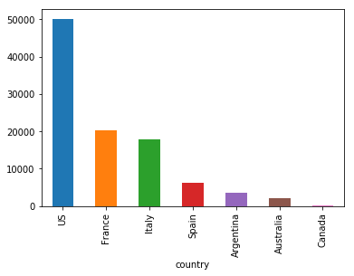

```python
country_distribution.plot(kind = 'bar')
plt.show()
```

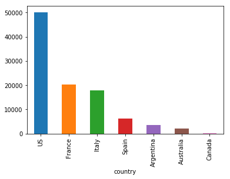

```python
country_distribution.plot(kind = 'bar')
plt.show()
plt.rcParams['figure.figsize']= [5,3]
```

Pop Quiz Add title and y - labels to the previous chart

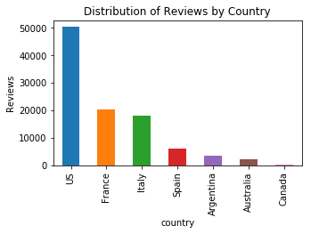

```python
country_distribution.plot(kind = 'bar')
plt.xlabel('country')
plt.ylabel('Reviews')
plt.title('Distribution of Reviews by Country')
plt.show()
```

```python
# build a scatterplot matrix
# build a build a correlation matrix in pandas
```

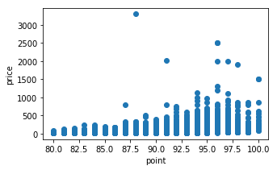

```python
plt.scatter(df.points, df.price_new)
plt.xlabel('point')
plt.ylabel('price')
plt.show()
```

```python
#histograms
```

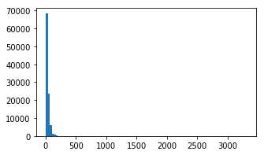

```python
plt.hist(df.price_new, bins = 100)
plt.show()
```

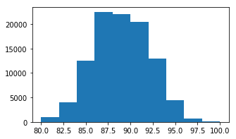

```python
plt.hist(df.points)
plt.show()
```

So, why is correlation useful

Correlation can help in predicting one quantity from another

This will become more relevant later as we accumulate more numeric indicators

## seaborn vs matplotlib

```python
df.corr()
```

|  | points | price_new |
| --- | --- | --- |
| points | 1.000000 | 0.401267 |
| price_new | 0.401267 | 1.000000 |

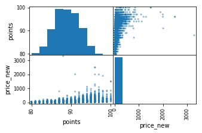

```python
pd.scatter_matrix(df)
plt.show()
plt.rcParams['figure.figsize']= [9,6]
```

```python
!pip install seaborn
```

```python
import seaborn as sns
print(f'seaborn version: {sns.__version__}')
```

```
seaborn version: 0.9.0
```

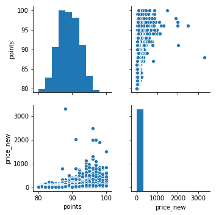

```python
sns.pairplot(df, kind = 'scatter')
plt.show()
```

### Final Lab for Visualization

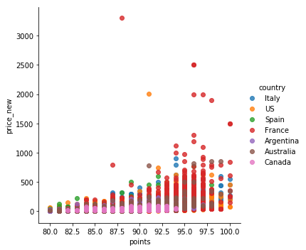

```python
sns.lmplot( x = 'points', y= 'price_new', data = df, fit_reg = False,  hue = 'country', legend = True)
plt.show()
```

## Data analysis

```python
df.groupby('country').agg(['mean'])
```

| country | points mean | price_new mean |
| --- | --- | --- |
| Argentina | 86.658941 | 24.786344 |
| Australia | 88.562386 | 35.707297 |
| Canada | 89.309735 | 35.787049 |
| France | 88.872942 | 41.046469 |
| Italy | 88.575678 | 39.539386 |
| Spain | 87.233426 | 28.299517 |
| US | 88.565973 | 36.773699 |

```python
df.groupby('country').agg(['mean', 'min', 'max'])
```

| country | points mean | points min | points max | price_new mean | price_new min | price_new max |
| --- | --- | --- | --- | --- | --- | --- |
| Argentina | 86.658941 | 80 | 97 | 24.786344 | 4.0 | 230.0 |
| Australia | 88.562386 | 80 | 100 | 35.707297 | 5.0 | 850.0 |
| Canada | 89.309735 | 82 | 94 | 35.787049 | 12.0 | 120.0 |
| France | 88.872942 | 80 | 100 | 41.046469 | 5.0 | 3300.0 |
| Italy | 88.575678 | 80 | 100 | 39.539386 | 5.0 | 900.0 |
| Spain | 87.233426 | 80 | 98 | 28.299517 | 4.0 | 770.0 |
| US | 88.565973 | 80 | 100 | 36.773699 | 4.0 | 2013.0 |

```python
df.variety.unique()
```

```
array(['White Blend', 'Pinot Gris', 'Riesling', 'Pinot Noir',
       'Tempranillo-Merlot', 'Frappato', 'Gewürztraminer',
       'Cabernet Sauvignon', 'Nerello Mascalese', 'Chardonnay', 'Malbec',
       'Tempranillo Blend', 'Meritage', 'Red Blend', 'Merlot',
       "Nero d'Avola", 'Chenin Blanc', 'Gamay', 'Sauvignon Blanc',
       'Primitivo', 'Catarratto', 'Inzolia', 'Monica',
       'Bordeaux-style White Blend', 'Grillo', 'Sangiovese',
       'Cabernet Franc', 'Champagne Blend', 'Bordeaux-style Red Blend',
       'Aglianico', 'Petite Sirah', 'Albariño', 'Petit Manseng', 'Rosé',
       'Zinfandel', 'Vernaccia', 'Rosato', 'Viognier', 'Vermentino',
       'Grenache Blanc', 'Syrah', 'Nebbiolo', 'Shiraz-Cabernet Sauvignon',
       'Pinot Blanc', 'Alsace white blend', 'Barbera',
       'Rhône-style Red Blend', 'Graciano', 'Tannat-Cabernet',
       'Sauvignon', 'Sangiovese Grosso', 'Torrontés', 'Prugnolo Gentile',
       'G-S-M', 'Verdejo', 'Fumé Blanc', 'Pinot Bianco', 'Bonarda',
       'Shiraz', 'Montepulciano', 'Moscato', 'Grenache',
       'Ugni Blanc-Colombard', 'Friulano', 'Carignan-Grenache',
       'Sagrantino', 'Savagnin', 'Cabernet Sauvignon-Syrah', 'Prosecco',
       'Vignoles', 'Sparkling Blend', 'Muscat', 'Muscadelle',
       'Shiraz-Viognier', 'Garganega', 'Pinot Grigio', 'Tempranillo',
       'Cortese', 'Mencía', 'Melon', 'Rhône-style White Blend', 'Vidal',
       'Cannonau', 'Verdelho', 'Marsanne', 'Kerner', 'Syrah-Grenache',
       'Dolcetto', 'Grüner Veltliner', 'Glera', 'Viura',
       'Garnacha Tintorera', 'Pinot Nero', 'Sémillon', 'Pinot Noir-Gamay',
       'Verdejo-Viura', 'Verduzzo', 'Verdicchio', 'Colombard',
       'Carricante', 'Sylvaner', 'Fiano', 'Roussanne', 'Cinsault',
       'Muscat Blanc à Petits Grains', 'Monastrell', 'Petit Verdot',
       'Xarel-lo', 'Greco', 'Trebbiano', 'Corvina, Rondinella, Molinara',
       'Chenin Blanc-Chardonnay', 'Insolia', 'Ribolla Gialla', 'Duras',
       'Tannat-Syrah', 'Marsanne-Roussanne', 'Charbono', 'Prié Blanc',
       'Sherry', 'Provence red blend', 'Tannat', 'Zibibbo', 'Falanghina',
       'Garnacha', 'Negroamaro', 'Mourvèdre', 'Syrah-Cabernet',
       'Müller-Thurgau', 'Pinot Meunier', 'Cabernet Sauvignon-Sangiovese',
       'Teroldego', 'Port', 'Pansa Blanca', 'Muskat Ottonel',
       'Sauvignon Blanc-Semillon', 'Claret', 'Semillon-Sauvignon Blanc',
       'Moscatel', 'Rosado', 'Viura-Chardonnay', 'Syrah-Viognier',
       'Cabernet Sauvignon-Merlot', 'Malvasia Bianca', 'Malbec-Merlot',
       'Monastrell-Syrah', 'Malbec-Tannat', 'Malbec-Cabernet Franc',
       'Turbiana', 'Refosco', 'Manzoni', 'Carmenère', 'Ruché',
       'Tinta de Toro', 'Traminette', 'Chambourcin', 'Nero di Troia',
```

[output cut: 90 more lines]

```
       'Chelois', 'Muscadel', 'Shiraz-Tempranillo',
       'Roussanne-Grenache Blanc', 'Biancale', 'Ansonica',
       'Syrah-Bonarda', 'Durif', 'Franconia', 'Malbec-Tempranillo',
       'Nasco', 'Monastrell-Petit Verdot', 'Sirica', 'Apple',
       'Pinot Grigio-Sauvignon Blanc', 'Viognier-Grenache Blanc',
       'Valvin Muscat', 'St. Vincent', 'Chancellor', 'Premsal',
       'Tokay Pinot Gris', 'Colorino', 'Picapoll', 'Tinta Madeira',
       'Centesimino', 'Grenache Gris', 'Merlot-Petite Verdot',
       'Catalanesca', 'Garnacha-Cabernet', 'Garnacha-Cariñena',
       'Cabernet Franc-Lemberger', 'Chardonnay-Albariño',
       'Shiraz-Mourvèdre', 'Favorita', 'Tintilia ', 'Petit Courbu',
       'Parraleta', 'Moscato di Noto', 'Roscetto', 'Silvaner',
       'Viognier-Valdiguié', 'Francisa', 'Chardonnay-Pinot Blanc',
       'Pignolo', 'Caprettone', 'Bobal-Cabernet Sauvignon', 'Alvarinho'],
      dtype=object)
```